# harpSpatial Test: harpSpatialTeam version

This notebook is a test of new developments in the harpSpatial package, currently in the harpSpatialTeam repository on Github. Here spatial verification is run on the same data that used for the current version of harpSpatial that is available in the harphub repository on Github.

```r
library(harp)
library(here)
obs_dir      <- here("..", "data", "met_analysis")
obs_template <- "met_analysis_1_0km_nordic_{YYYY}{MM}{DD}T{HH}Z.nc"
obs_opts     <- netcdf_opts(proj4_var = "projection_lcc", lon_var = NULL, lat_var = NULL)

fcst_dir      <- here("..", "data", "meps")
fcst_template <- "meps_det_2_5km_{YYYY}{MM}{DD}T{HH}Z.nc"
fcst_opts     <- netcdf_opts(ref_time_var = NA, z_var = "height0")

start_date <- 2022081500
end_date   <- start_date
```

Set the verification domain by reading in a forecast field and subgridding. Note that here the harpSpatialTeam version of harpVis is used that doesn’t include the `get_domain()` function, so the domain is extracted a slightly more cumbersome way.

```r
dom <- read_forecast(
  date_times          = 2022081500,
  fcst_model          = "meps",
  parameter           = "Pcp",
  lead_time           = 0,
  file_path           = fcst_dir,
  file_template       = fcst_template,
  file_format_opts    = fcst_opts,
  transformation      = "subgrid",
  transformation_opts = subgrid_opts(172, 472, 180, 480),
  return_data         = TRUE
)[[1]][["meps_det"]][[1]] %>%
  meteogrid::as.geodomain()
```

Plot the verif domain, just to make sure we got the correct one

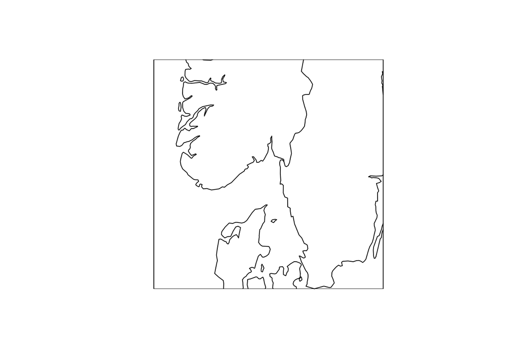

```r
plot(dom)
```

Now it’s time to do the verification using `verifiy_spatial()`. Note that `param_find` needs to be used to map to the variable names in the netcdf files.

```r
verif <- verify_spatial(
  start_date       = start_date,
  end_date         = end_date,
  parameter        = "AccPcp1h",
  model            = "meps",
  lead_time        = seq(0, 48),
  fc_file_path     = fcst_dir,
  fc_file_template = fcst_template,
  fc_options = modify_opts(
    fcst_opts,
    param_find = list(AccPcp1h = "precipitation_amount_acc")
  ),
  ob_file_path     = obs_dir,
  ob_file_template = obs_template,
  ob_options       = modify_opts(
    obs_opts,
    param_find = list(AccPcp1h = "precipitation_amount")
  ),
  ob_accumulation  = "1h",
  verif_domain     = dom
)
```

Now that the verification is done, the output can be inspected.

```r
verif
```

```
$bias
# A tibble: 48 × 5
   model prm          fcdate leadtime  bias
   <chr> <chr>         <dbl>    <dbl> <dbl>
 1 meps  AccPcp1h 1660521600     3600    NA
 2 meps  AccPcp1h 1660521600     7200    NA
 3 meps  AccPcp1h 1660521600    10800    NA
 4 meps  AccPcp1h 1660521600    14400    NA
 5 meps  AccPcp1h 1660521600    18000    NA
 6 meps  AccPcp1h 1660521600    21600    NA
 7 meps  AccPcp1h 1660521600    25200    NA
 8 meps  AccPcp1h 1660521600    28800    NA
 9 meps  AccPcp1h 1660521600    32400    NA
10 meps  AccPcp1h 1660521600    36000    NA
# … with 38 more rows

$mse
# A tibble: 48 × 5
   model prm          fcdate leadtime   mse
   <chr> <chr>         <dbl>    <dbl> <dbl>
 1 meps  AccPcp1h 1660521600     3600    NA
 2 meps  AccPcp1h 1660521600     7200    NA
 3 meps  AccPcp1h 1660521600    10800    NA
 4 meps  AccPcp1h 1660521600    14400    NA
 5 meps  AccPcp1h 1660521600    18000    NA
 6 meps  AccPcp1h 1660521600    21600    NA
 7 meps  AccPcp1h 1660521600    25200    NA
 8 meps  AccPcp1h 1660521600    28800    NA
 9 meps  AccPcp1h 1660521600    32400    NA
10 meps  AccPcp1h 1660521600    36000    NA
# … with 38 more rows

$mae
# A tibble: 48 × 5
   model prm          fcdate leadtime   mae
   <chr> <chr>         <dbl>    <dbl> <dbl>
 1 meps  AccPcp1h 1660521600     3600    NA
 2 meps  AccPcp1h 1660521600     7200    NA
 3 meps  AccPcp1h 1660521600    10800    NA
 4 meps  AccPcp1h 1660521600    14400    NA
```

[output cut: 40 more lines]

```
$NACT
# A tibble: 1,344 × 10
   model prm          fcdate leadt…¹ thres…² scale       a       b       c     d
   <chr> <chr>         <dbl>   <dbl>   <dbl> <dbl>   <dbl>   <dbl>   <dbl> <dbl>
 1 meps  AccPcp1h 1660521600    3600     0.1     0 0.0185  0.00806 0.0107  0.963
 2 meps  AccPcp1h 1660521600    3600     0.1     1 0.0187  0.00782 0.0105  0.963
 3 meps  AccPcp1h 1660521600    3600     0.1     2 0.0190  0.00751 0.0102  0.963
 4 meps  AccPcp1h 1660521600    3600     0.1     4 0.0196  0.00685 0.00951 0.964
 5 meps  AccPcp1h 1660521600    3600     0.1     8 0.0208  0.00560 0.00827 0.965
 6 meps  AccPcp1h 1660521600    3600     0.1    12 0.0219  0.00450 0.00718 0.966
 7 meps  AccPcp1h 1660521600    3600     0.1    20 0.0231  0.00320 0.00592 0.968
 8 meps  AccPcp1h 1660521600    3600     1       0 0.00217 0.00189 0.00203 0.994
 9 meps  AccPcp1h 1660521600    3600     1       1 0.00228 0.00178 0.00192 0.994
10 meps  AccPcp1h 1660521600    3600     1       2 0.00240 0.00165 0.00180 0.994
# … with 1,334 more rows, and abbreviated variable names ¹leadtime, ²threshold
```

There may be some issues with the likes of bias, mse, rmse etc. as they are all `NA`.

For plotting, the harpSpatialTeam version of harpVis should be updated to be compatible with these outputs.

```r
#plot_spatial_verif(verif, FSS)
#plot_spatial_verif(verif, SAL)
```

The problem is in extracting the correct data frame (it is done with `verif_data$score_name` instead of `verif_data[[score_name]]`). There is a missing function when it comes to plotting the FSS, but SAL works if you just send it the data frame! However, as some of the functions used in the code are not properly namespaced, we need to make sure that the dplyr library is attached.

```
Multiple leadtimes found: 1 2 3 4 5 6 7 8 9 10 11 12 13 14 15 16 17 18 19 20 21 22 23 24 25 26 27 28 29 30 31 32 33 34 35 36 37 38 39 40 41 42 43 44 45 46 47 48
```

```
Plotting score: SAL
```

```
Plots complete!
```

[output not shown]

[figure not shown]

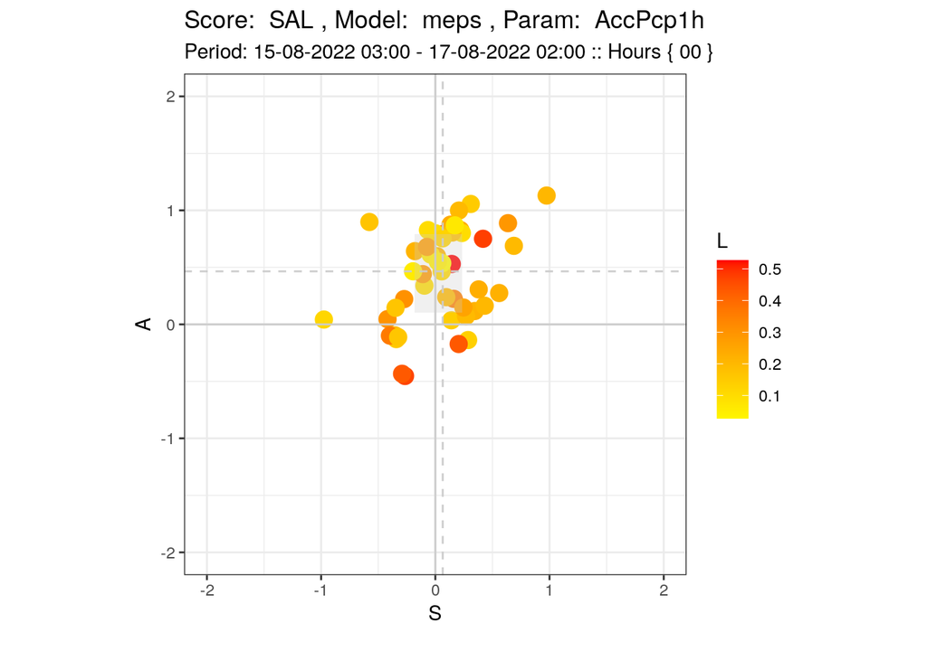

```r
library(dplyr)
plot_spatial_verif(verif$SAL, SAL) +
  coord_equal()
```

For FSS we have to go back to ggplot

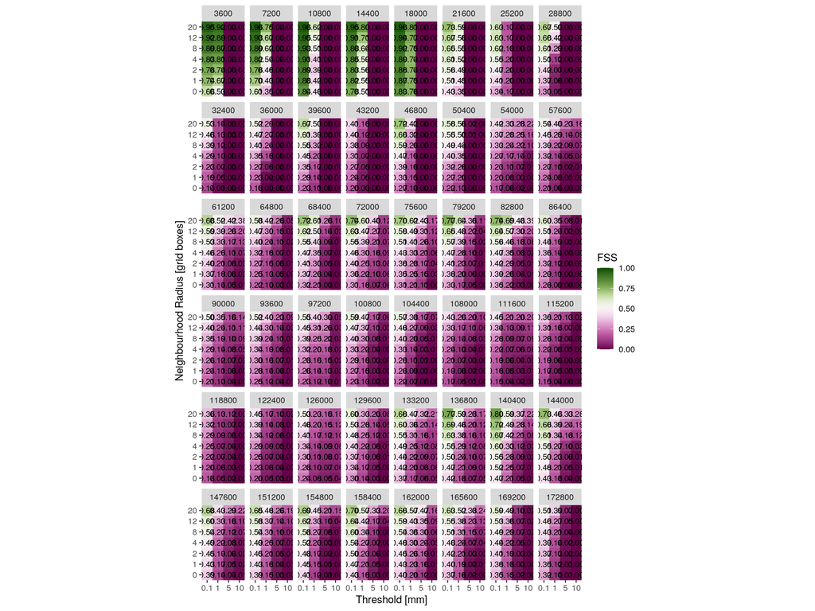

```r
ggplot(
  verif$FSS,
  aes(
    factor(threshold),
    factor(scale),
    fill = fss,
    label = sprintf("%1.2f", fss)
  )
) +
  geom_raster() +
  geom_text(size = 3) +
  facet_wrap(vars(leadtime), ncol = 8) +
  scico::scale_fill_scico(
    "FSS", palette = "bam", limits = c(0, 1)
  ) +
  coord_equal(expand = FALSE) +
  labs(
    x = "Threshold [mm]",
    y = "Neighbourhood Radius [grid boxes]"
  )
```

Note that here, the spatial scale is expressed as the neighbourhood radius rather than the neighbourhood length as in the harphub version. Also the lead time is always in seconds, which isn’t necessarily ideal but could easily be converted in the aesthetic setting (e.g. `factor(leadtime / 3600)`)

The alternative method is to use a configuration file… There is a configuration file under `harpspatialteam/conf`

```r
harpSpatial_read_config(here("conf", "my_conf.R"))
```

```
$by
[1] "12h"

$fc_accumulation
NULL

$fc_domain
NULL

$fc_file_format
NULL

$fc_file_path
[1] "/home/andrewts/harpSpatial_ww/harp-ww-feb2023/harpspatialteam/../data/meps"

$fc_file_template
[1] "meps_det_2_5km_{YYYY}{MM}{DD}T{HH}Z.nc"

$fc_interp_method
[1] "closest"

$fc_options
$fc_options$options_set
[1] "none"

$fc_options$param_find
$fc_options$param_find$AccPcp1h
[1] "precipitation_amount_acc"

$fc_options$param_find$AccPcp3h
[1] "precipitation_amount_acc"

$fc_options$param_find$AccPcp6h
[1] "precipitation_amount_acc"

$fc_options$param_find$AccPcp12h
[1] "precipitation_amount_acc"

$fc_options$param_find$AccPcp24h
[1] "precipitation_amount_acc"
```

[output cut: 168 more lines]

```

$thresholds
[1]  0.1  1.0  5.0 10.0

$use_mask
[1] FALSE

$verif_domain
301 x 301 domain
Projection summary:
proj= lcc
centre = ( 10.55944 , 58.63803 )

$window_sizes
[1]  0  1  2  4  8 12 20
```

[output not shown]

[output not shown]

[output not shown]

[output not shown]

[output not shown]

[output not shown]

[output not shown]

[output not shown]

[output not shown]

[output not shown]

[output not shown]

[output not shown]

[output not shown]

[output not shown]

[output not shown]

[output not shown]

[output not shown]

[output not shown]

[output not shown]

[output not shown]

[output not shown]

[output not shown]

[output not shown]

[output not shown]

[output not shown]

[output not shown]

[output not shown]

[output not shown]

[output not shown]

[output not shown]

[output not shown]

[output not shown]

[output not shown]

[output not shown]

```r
verif_from_conf <- verify_spatial(
  start_date = start_date,
  end_date   = end_date,
  parameter  = "AccPcp1h",
  model      = "meps"
)
```

We can check that we got the same result using `identical()`

```r
identical(verif, verif_from_conf)
```

```
[1] TRUE
```